# Logistic regression

WiSe23/24

Daniela Palleschi

Humboldt-Universität zu Berlin

2023-10-11

# Learning Objectives

Today we will learn…

- how to model binomial data with logistic regression
- how to interpret log-odds and odds ratio
- how to report a logistic regression model

# Resources

- this lecture covers chapter 12 'Genearlised Lienar Models 1: Logistic Regression’ (Winter, 2019)
  - we’re skipping a few chapters, which I encourage you to go through on your own
  - they cover topics that you presumably have covered in previous courses (namely significance testing, *t*-values and *p*-values).

# Set-up environment

```r
# suppress scientific notation
options(scipen=999)
options(pillar.sigfig = 5)
```

```r
# load libraries
pacman::p_load(
               tidyverse,
               here,
               broom,
               janitor,
               languageR)
```

```r
# set preferred ggplot2 theme
theme_set(theme_bw() + theme(plot.title = element_text(size = 10)))
```

# Generalised linear models

- linear regression assumes a normal distribution
  - Equation $\ref{eq-normal}$, where $\mu$ and $\sigma$ correspond to the mean and standard deviation
- logistic regression assumes a binomial distribution (a.k.a., Bernoulli distribution)
  - Equation $\ref{eq-binomial}$, where $N$ and $p$ correspond to the number of trials and the probability of $y$ being $1$ or $0$

$$\begin{align}
y &\sim Normal(\mu,\sigma) \label{eq-normal} \\
y &\sim binomial(N = 1, p) \label{eq-binomial}
\end{align}$$

- logistic regression is a type of genearlised linear model (GLM)
  - used to model binomial response data

## Log-odds, odds ratio, and probabilities

- logistic regression describes the *probability* ($p$) of observing one outcome or another as a function of a predictor variable
  - e.g., the absence or presence of some phenomenon (word order, schwa, etc.) or button responses (yes/no, accept/reject)
- this can be described as the probability, odds, or log-odds of a particular outcome over another

### Probability

- probability ranges from 0 (no chance) to 1 (certain)
  - 50% chance = probability of 0.5

### Odds (ratio)

- odds range from 0 to infinity
  - *the odds that I’ll win are 2:1* ($\frac{2}{1} = 2$ in favour of my winning)
  - *the odds that you’ll win are 1:2*($\frac{1}{2} = 0.5$)
  - if the odds are even (1:1), then: $\frac{1}{1} = 1$
- odds of 1 correspond to a probability of 0.5

### Log-odds

- log-odds are just the logarithmically-transformed odds
  - $log(2) =$ 0.6931472
  - $log(0.5) =$ -0.6931472
  - $log(1) =$ 0
- so the log-odds of 0 correspond to a probability of 0.5 (and odds of 1)

## Comparing odds/log-odds/probability

- Table 1 gives an example of how the three relate to each other
  - did you get the correct values?

Table 1: Comparison of different values of probabilities/odds/log-odds

| prob | 0.007 | 0.023 | 0.076 | 0.223 | 0.5 | 0.777 | 0.924 | 0.977 | 0.993 |
| --- | --- | --- | --- | --- | --- | --- | --- | --- | --- |
| odds | 0.007 | 0.024 | 0.082 | 0.287 | 1.0 | 3.490 | 12.182 | 42.521 | 148.413 |
| log_odds | -5.000 | -3.750 | -2.500 | -1.250 | 0.0 | 1.250 | 2.500 | 3.750 | 5.000 |

- try the task again, this time using `plogis()`, which produces a probility from a log odds

## Plotting odds/log-odds/probability

- this relationship is demonstrated in Figure 1
- take your time to really understand these plots

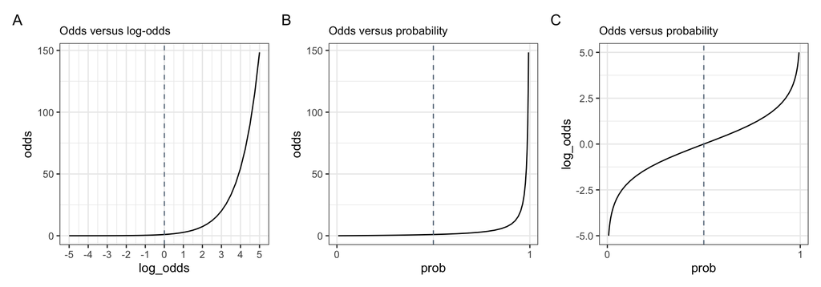

Figure 1: Relationship between probability, odds, and log-odds

# Logistic regression

- let’s run our first logistic regression to understand this relationship better
- Most relevant to the output of a logistic regression model is Figure 1 C
  - the model will output log-odds, and we most likely want to interpret them in terms of probabilities

## Load data

- load in the Biondo et al. (2022) dataset again
  - let’s look at the binomial measure *regression in* at the *verb* region

```r
df_tense <-
  read_csv(here("data", "Biondo.Soilemezidi.Mancini_dataset_ET.csv"),
           locale = locale(encoding = "Latin1") # for special characters in Spanish
           ) |>
  clean_names() |>
  mutate(gramm = ifelse(gramm == "0", "ungramm", "gramm"))  |>
  filter(roi == 4,
         adv_type == "Deic")
```

## EDA

- conduct a quick EDA: print head of data

```r
head(df_tense)
```

```
# A tibble: 6 × 13
  sj     item adv_type adv_t  verb_t gramm     roi label    fp    gp    tt    ri
  <chr> <dbl> <chr>    <chr>  <chr>  <chr>   <dbl> <chr> <dbl> <dbl> <dbl> <dbl>
1 1        54 Deic     Past   Past   gramm       4 enca…  1027  1027  1027     0
2 1         4 Deic     Future Future gramm       4 cole…   562   562  1337     1
3 1        62 Deic     Past   Past   gramm       4 esqu…   293  1664  1141     0
4 1        96 Deic     Future Past   ungramm     4 cons…   713  1963  1868     0
5 1        52 Deic     Past   Past   gramm       4 desa…   890   890  1707     1
6 1        90 Deic     Future Past   ungramm     4 dece…   962   962   962     0
# ℹ 1 more variable: ro <dbl>
```

- and summary

```r
df_tense |>
  select(roi, ri, ro) |>
  summary()
```

```
      roi          ri               ro
 Min.   :4   Min.   :0.0000   Min.   :0.00000
 1st Qu.:4   1st Qu.:0.0000   1st Qu.:0.00000
 Median :4   Median :0.0000   Median :0.00000
 Mean   :4   Mean   :0.2248   Mean   :0.08169
 3rd Qu.:4   3rd Qu.:0.0000   3rd Qu.:0.00000
 Max.   :4   Max.   :1.0000   Max.   :1.00000
             NA's   :45       NA's   :45
```

### Plot

- let’s plot the count of yes/no for regressions in

```r
facet_labels <-
  c(
    "ri" = "Reg. In",
    "ro" = "Reg. Out",
    "Future" = "Future",
    "Past" = "Past"
  )

# fig_reg <-
  df_tense |>
  filter(roi == "4") |>
  mutate(gramm = as_factor(gramm),
         ri = ifelse(ri == 1, "yes", "no")) |>
  drop_na(ri) |>
  ggplot() +
  labs(title = "Count of regressions in") +
  aes(x = gramm, fill = ri) +
  geom_bar() +
  facet_grid(.~verb_t, labeller = as_labeller(facet_labels))
```

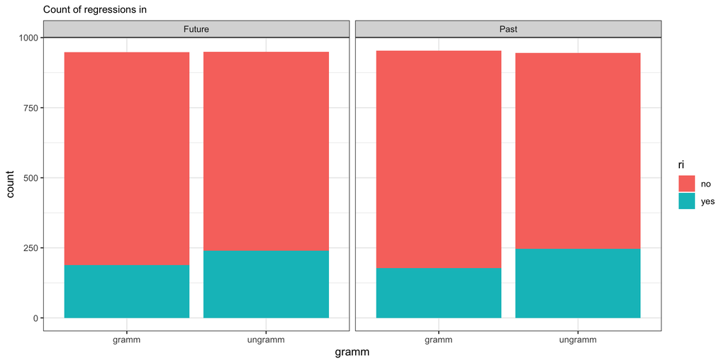